# Task_C_Additional_data_analysis

```python
import math
import networkx as nx
import wikipediaapi, time, json,requests,os
from collections import Counter
import numpy as np
import random
import matplotlib.pyplot as plt
import datetime
import ast
import re
```

```python
def load_people_json(filename):
    with open(filename, "r") as pfile:
        return json.load(pfile)

filename="politicians.json"

politicians=load_people_json(filename)

filename="finns-1900-1940.json"

finns=load_people_json(filename)

filename="artists-1900-current.json"

artists=load_people_json(filename)
```

```python
politicians['Benedict_Calvert,_4th_Baron_Baltimore']
```

```
{'#DBpURL': 'http://dbpedia.org/resource/Benedict_Calvert,_4th_Baron_Baltimore',
 'ID': '21',
 'WikiURL': 'http://en.wikipedia.org/wiki/Benedict_Calvert,_4th_Baron_Baltimore',
 'gender': 'M',
 'name': "[' (the right honourable) ', ' the lord baltimore ']",
 'birthDate': "[' 1679-03-21 ']",
 'deathDate': "[' 1715-04-16 ']",
 'occupation': "[' politician ']",
 'nationality': 'NA',
 'party': 'NA',
 'summary': "Benedict Leonard Calvert, 4th Baron Baltimore (21 March 1679 – 16 April 1715) was an English nobleman and politician. He was the second son of Charles Calvert, 3rd Baron Baltimore (1637–1715) by Jane Lowe, and became his father's heir upon the death of his elder brother Cecil in 1681. T…
 'langs': ['de', 'fr', 'ja', 'pl'],
 'links': ['Benedict_Leonard_Calvert',
  'Benedict_Swingate_Calvert',
  'Charles_Calvert,_5th_Baron_Baltimore',
  'Henry_Darnall',
  'Sir_Robert_Eden,_1st_Baronet,_of_Maryland']}
```

# Task C: Additional data analysis (200 points)

For this task, please feel free to test out your own analysis ideas or focus on things you find most interesting. You can replicate ideas from the source article or develop your own.

Note that the data will contain errors and missing data, so you must deal with them in your analysis. Here are some ideas that you can try out or just be inspired by:

Question 1

Test if there is homophily related to gender in the politician network. Find the number of links between the different genders and compare it to the baseline case if nodes would have been randomly linking to each other (while keeping the degrees of the nodes fixed). You estimate the number of links between genders in the baseline case by randomising the network explicitly.

```python
network = nx.Graph()

colors_dict = {'M': 'blue', 'F': 'red'}
gender_dict = {'M': 'Male', 'F':'Female'}

for name, data in politicians.items():
    # The links attribute is of type List[str]
    for link in data.get("links", []):
        if name != link and data['gender'] != 'NA' and politicians[link]['gender'] != 'NA':
            network.add_node(name, gender= data['gender'], color=colors_dict[data['gender']])
            network.add_node(link, gender= politicians[link]['gender'], color=colors_dict[politicians[link]['gender']])
            network.add_edge(name, link)
num_edges = network.number_of_edges()
print("Number of edges in the network:", num_edges)
```

```
Number of edges in the network: 5736
```

```python
# Initialize variables to count number of links between genders
num_links_female_female = 0
num_links_female_male = 0
num_links_male_male = 0

# Iterate through edges in the network
for edge in network.edges():
    # Get the genders of the two nodes in the edge
    gender1 = politicians[edge[0]]['gender']
    gender2 = politicians[edge[1]]['gender']

    # Increment the appropriate gender link count
    if gender1 == 'F' and gender2 == 'F':
        num_links_female_female += 1
    elif (gender1 == 'F' and gender2 == 'M') or (gender1 == 'M' and gender2 == 'F'):
        num_links_female_male += 1
    elif gender1 == 'M' and gender2 == 'M':
        num_links_male_male += 1

# Print the results
print("Number of links between females in original network: ", num_links_female_female)
print("Number of links between females and males in original network: ", num_links_female_male)
print("Number of links between males in original network: ", num_links_male_male)
```

```
Number of links between females in original network:  320
Number of links between females and males in original network:  1622
Number of links between males in original network:  3794
```

To randomize the network while keeping the degrees of the nodes fixed, we can use a method called edge swapping. The basic idea of edge swapping is to randomly select two edges and swap their endpoints, as long as the new edges do not already exist in the network. This can be done iteratively until the network is sufficiently randomized.

```python
# Create a copy of the original network
network_random = network.copy()

# Perform edge swapping
for i in range(3000):
    # Randomly select two edges
    edges = list(network_random.edges())
    #print(edges[0])
    u1, v1 = random.choice(edges)
    u2, v2 = random.choice(edges)

    # Check if new edges already exist
    if not network_random.has_edge(u1, v2) and not network_random.has_edge(u2, v1):
        # Swap endpoints of the edges
        network_random.add_edge(u1, v2)
        network_random.add_edge(u2, v1)
        network_random.remove_edge(u1, v1)
        network_random.remove_edge(u2, v2)
```

```python
# Initialize variables to count number of links between genders
num_links_female_female_random = 0
num_links_female_male_random = 0
num_links_male_male_random = 0

# Iterate through edges in the network
for edge in network_random.edges():
    # Get the genders of the two nodes in the edge
    gender1 = politicians[edge[0]]['gender']
    gender2 = politicians[edge[1]]['gender']

    # Increment the appropriate gender link count
    if gender1 == 'F' and gender2 == 'F':
        num_links_female_female_random += 1
    elif (gender1 == 'F' and gender2 == 'M') or (gender1 == 'M' and gender2 == 'F'):
        num_links_female_male_random += 1
    elif gender1 == 'M' and gender2 == 'M':
        num_links_male_male_random += 1

# Print the results
print("Number of links between females in baseline network: ", num_links_female_female_random)
print("Number of links between females and males in baseline network: ", num_links_female_male_random)
print("Number of links between males in baseline network: ", num_links_male_male_random)
```

```
Number of links between females in baseline network:  267
Number of links between females and males in baseline network:  1728
Number of links between males in baseline network:  3741
```

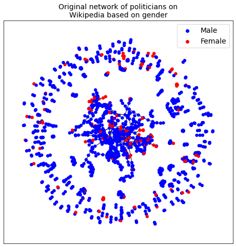

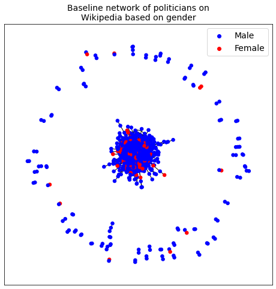

```python
random.seed(123)  # Set random seed for reproducibility



fontsize=14
colors = [node[1]['color'] for node in network.nodes(data=True)]

positions = nx.spring_layout(network) # Find locations for the nodes using spring layout algorithm
# Define node colors based on gender

plt.figure(figsize=(8, 8))  # Set the figure size
nx.draw_networkx(network, pos=positions, node_color=colors, node_size=30, with_labels=False)

for gender in colors_dict:
    plt.scatter([],[], c=colors_dict[gender], label=gender_dict[gender])

plt.legend(fontsize=fontsize)

plt.title("Original network of politicians on\nWikipedia based on gender", fontsize=fontsize)

plt.show()

plt.figure(figsize=(8, 8))  # Set the figure size

positions = nx.spring_layout(network_random) # Find locations for the nodes using spring layout algorithm
# Define node colors based on gender

nx.draw_networkx(network_random, pos=positions, node_color=colors, node_size=30, with_labels=False)

for gender in colors_dict:
    plt.scatter([],[], c=colors_dict[gender], label=gender_dict[gender])

plt.legend(fontsize=fontsize)

plt.title("Baseline network of politicians on\nWikipedia based on gender", fontsize=fontsize)

plt.show()
```

[figure not shown]

```python
random.seed(123)  # Set random seed for reproducibility

positions = nx.spring_layout(network) # Find locations for the nodes using spring layout algorithm
# Define node colors based on gender

fontsize=15
colors = [node[1]['color'] for node in network.nodes(data=True)]

plt.figure(figsize=(8, 8))  # Set the figure size
nx.draw_networkx(network, pos=positions, node_color=colors, node_size=30, with_labels=False)

for gender in colors_dict:
    plt.scatter([],[], c=colors_dict[gender], label=gender_dict[gender])

plt.legend(fontsize=fontsize)

plt.title("Original network of politicians on\nWikipedia based on gender",fontsize=fontsize)

plt.figure(figsize=(8, 8))  # Set the figure size
nx.draw_networkx(network, pos=positions, node_color=colors, node_size=30, with_labels=False)

for gender in colors_dict:
    plt.scatter([],[], c=colors_dict[gender], label=gender_dict[gender])

plt.legend(fontsize=fontsize)

plt.title("Baseline network of politicians on\nWikipedia based on gender",fontsize=fontsize)
```

Question 2

Replicate the analysis of comparing if females/males are more likely to be “local heroes,” i.e., if it is true that females are more likely to be in a larger number of language editions than males. Try out different ways of operationalizing this. Then analyze the glass-ceiling effect of entry into Wikipedia.

```python
gender_counts = {'M': {}, 'F': {}, 'NA': {}}

female_politicians = {name: data for name, data in politicians.items() if data["gender"] == "F"}

num_female = len(female_politicians)

male_politicians = {name: data for name, data in politicians.items() if data["gender"] == "M"}

num_male = len(male_politicians)

NA_politicians = {name: data for name, data in politicians.items() if data["gender"] == "NA"}

num_NA = len(NA_politicians)

count = {'M': num_male, 'F': num_female, 'NA': num_NA}
for name, data in politicians.items():
    gender = data['gender']
    langs = data['langs']

    for lang in langs:
        if lang not in gender_counts[gender]:
            gender_counts[gender][lang] = 1
        else:
            gender_counts[gender][lang] += 1

number_lang_editions_male = sum(gender_counts['M'].values())
number_lang_editions_female = sum(gender_counts['F'].values())
```

```
Mean number of language editions for male politicians: 6.065608
Mean number of language editions for female politicians: 6.702073
Number of languages covering more female politicians than male politicians: 88
Number of languages covering more male politicians than female politicians: 67
```

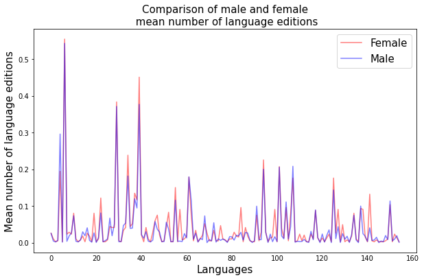

```python
print("Mean number of language editions for male politicians: {:3f}".format(number_lang_editions_male/num_male))
print("Mean number of language editions for female politicians: {:3f}".format(number_lang_editions_female/num_female))

for gender in gender_counts:
    for lang in gender_counts[gender]:
        gender_counts[gender][lang] /= count[gender]


sorted_counts = dict(sorted(gender_counts['M'].items(), key=lambda x: x[1], reverse=True))

common_langs = sorted(list(set(gender_counts['M'].keys()).intersection(set(gender_counts['F'].keys()))))

num_females_morethan_males = 0
num_males_morethan_females = 0

num_females_morethan_males_list = []
num_males_morethan_females_list = []

for lang in common_langs:
    if gender_counts['M'][lang] > gender_counts['F'][lang]:
        num_males_morethan_females += 1
        num_males_morethan_females_list.append(lang)
    elif gender_counts['M'][lang] < gender_counts['F'][lang]:
        num_females_morethan_males += 1
        num_females_morethan_males_list.append(lang)

print(f"Number of languages covering more female politicians than male politicians: {num_females_morethan_males}")
print(f"Number of languages covering more male politicians than female politicians: {num_males_morethan_females}")

females_mean_list = []
males_mean_list = []
for lang in common_langs:
    males_mean_list.append(gender_counts['M'][lang])
    females_mean_list.append(gender_counts['F'][lang])

fontsize=15
plt.figure(figsize=(10,6))
plt.tick_params(axis='x', which='both', length=0)
plt.plot(range(0, len(females_mean_list)), females_mean_list, label="Female", c='r', alpha=0.5)
plt.plot(range(0, len(males_mean_list)), males_mean_list, label="Male", c='b', alpha=0.5)

plt.xlabel("Languages",fontsize=fontsize)
plt.ylabel("Mean number of language editions",fontsize=fontsize)
plt.title("Comparison of male and female\n mean number of language editions",fontsize=fontsize)
plt.legend(fontsize=fontsize)
```

Question 3

Explore how the language used to describe men and women in their summary texts differs. You could do this by counting gendered words (e.g., she, her, wife) or comparing the usage of terms related to personal life (e.g., father, daughter, married) with professional terms’ usage (e.g., leader, president, politician).

```python
male_politicians = {name: data for name, data in politicians.items() if data["gender"] == "M"}

num_male = len(male_politicians)

female_politicians = {name: data for name, data in politicians.items() if data["gender"] == "F"}

num_female = len(female_politicians)

# Concatenate all summaries into a single string
all_summaries = " ".join([data["summary"] for data in politicians.values()])

# Separate summaries by gender
male_summaries = " ".join([data["summary"] for data in politicians.values() if data["gender"] == "M"])
female_summaries = " ".join([data["summary"] for data in politicians.values() if data["gender"] == "F"])

# Count occurrences of personal and professional terms
family_terms = ["husband", "wife", "spouse", "mother", "mom", "father", "dad", "son", "daughter", "married", "divorced", "family", "child", "children"]
professional_terms = ["leader", "president", "prime", "minister", "politician", "government", "parliamenet", "official", "public", "service", "governor", "senator"]

male_family_counts = sum([male_summaries.lower().count(term) for term in family_terms])/num_male
female_family_counts = sum([female_summaries.lower().count(term) for term in family_terms])/num_female
male_professional_counts = sum([male_summaries.lower().count(term) for term in professional_terms])/num_male
female_professional_counts = sum([female_summaries.lower().count(term) for term in professional_terms])/num_female

# Print results
print(f"Personal terms: Male: {male_family_counts}, Female: {female_family_counts}")
print(f"Professional terms: Male: {male_professional_counts}, Female: {female_professional_counts}")
```

```
Personal terms: Male: 0.7156966490299823, Female: 0.7124352331606217
Professional terms: Male: 2.4617283950617286, Female: 2.4145077720207255
```

Question 4

Visualise the network structure between the politicians. You can color nodes with different attributes or take subsamples. You can also attempt clustering the network and inspecting the clusters.

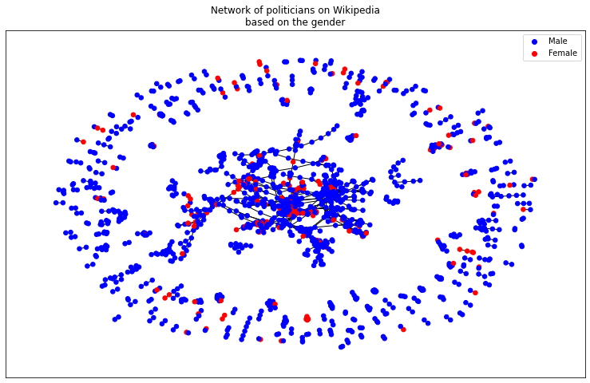

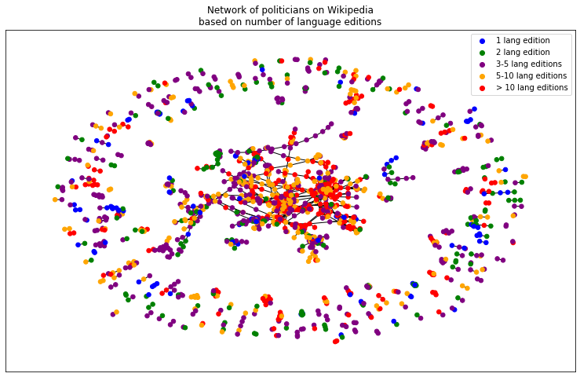

```python
random.seed(123)  # Set random seed for reproducibility

colors_dict = {'M': 'blue', 'F': 'red'}
gender_dict = {'M': 'Male', 'F':'Female'}
lang_editions_dict = {
                      1: 'blue',
                      2: 'green',
                      3: 'purple',
                      4: 'purple',
                      5: 'purple',
                      6: 'orange',
                      7: 'orange',
                      8: 'orange',
                      9: 'orange',
                      10: 'orange'
                    }

lang_editions_color = {
                      '1 lang edition': 'blue',
                      '2 lang edition': 'green',
                      '3-5 lang editions': 'purple',
                      '5-10 lang editions': 'orange',
                      '> 10 lang editions': 'red',
                    }

network_plot = nx.Graph()
for name, data in politicians.items():
    #network.add_node(name, gender=data["gender"])
    for link in data["links"]:
        if link in politicians:
            if name != link and data['gender'] != 'NA' and politicians[link]['gender'] != 'NA':
                length_langs_current = len(data['langs']) + 1
                length_langs_neighbor = len(politicians[link]['langs']) + 1
                if length_langs_current > 10:
                    color_lang_current = 'red'
                else:
                    color_lang_current = lang_editions_dict[length_langs_current]

                if length_langs_neighbor > 10:
                    color_lang_neighbor = 'red'
                else:
                    color_lang_neighbor = lang_editions_dict[length_langs_neighbor]

                network_plot.add_node(name, gender= data['gender'], color_gender=colors_dict[data['gender']], color_lang=color_lang_current)
                network_plot.add_node(link, gender= politicians[link]['gender'], color_gender=colors_dict[politicians[link]['gender']], color_lang=color_lang_neighbor)
                network_plot.add_edge(name, link)

fontsize = 10
positions = nx.spring_layout(network_plot ) # Find locations for the nodes using spring layout algorithm
# Define node colors based on gender

colors_gender = [node[1]['color_gender'] for node in network_plot.nodes(data=True)]

plt.figure(figsize=(13, 8))  # Set the figure size
nx.draw_networkx(network_plot , pos=positions, node_color=colors_gender, node_size=30, with_labels=False)

for gender in colors_dict:
    plt.scatter([],[], c=colors_dict[gender], label=gender_dict[gender])

plt.legend(loc=1,fontsize=fontsize)

plt.title("Network of politicians on Wikipedia\nbased on the gender", fontsize=fontsize+2)

plt.show()


# Define node colors based on language editions

colors_lang = [node[1]['color_lang'] for node in network_plot.nodes(data=True)]

plt.figure(figsize=(13, 8))  # Set the figure size
nx.draw_networkx(network_plot , pos=positions, node_color=colors_lang, node_size=30, with_labels=False)

for numberOfLangs in lang_editions_color:
    plt.scatter([],[], c=lang_editions_color[numberOfLangs], label=numberOfLangs)

plt.legend(loc=1,fontsize=fontsize)

plt.title("Network of politicians on Wikipedia\nbased on number of language editions", fontsize=fontsize+2)

plt.show()
```

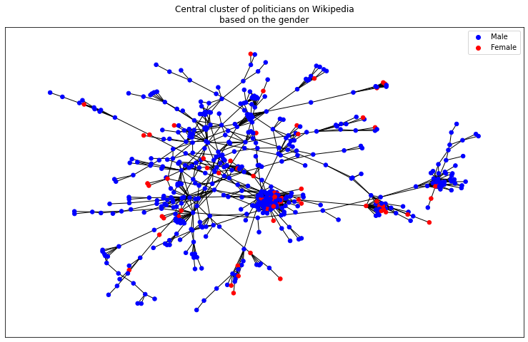

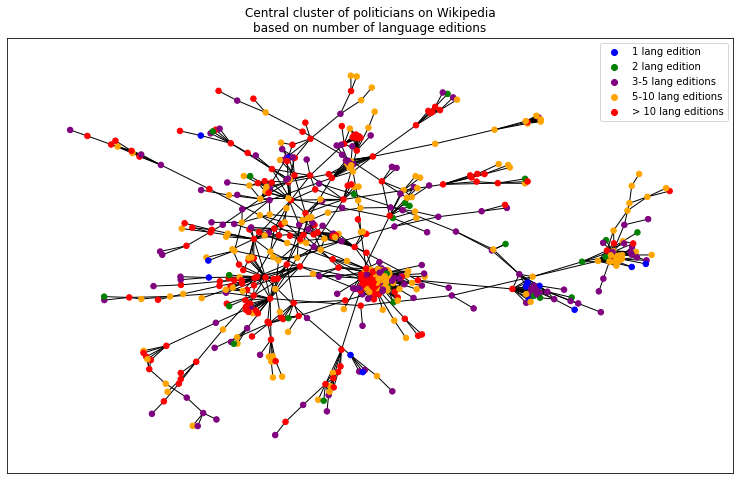

```python
# identify the largest connected component
largest_cc = max(nx.connected_components(network_plot), key=len)

# plot the largest connected component
network_main_cluster = network_plot.subgraph(largest_cc)

positions = nx.spring_layout(network_main_cluster) # Find locations for the nodes using spring layout algorithm

colors_gender = [node[1]['color_gender'] for node in network_main_cluster.nodes(data=True)]

plt.figure(figsize=(13, 8))  # Set the figure size
nx.draw_networkx(network_main_cluster , pos=positions, node_color=colors_gender, node_size=30, with_labels=False)

for gender in colors_dict:
    plt.scatter([],[], c=colors_dict[gender], label=gender_dict[gender])

plt.legend(loc=1,fontsize=fontsize)

plt.title("Central cluster of politicians on Wikipedia\nbased on the gender", fontsize=fontsize+2)

plt.show()

############################################

colors_lang = [node[1]['color_lang'] for node in network_main_cluster.nodes(data=True)]

plt.figure(figsize=(13, 8))  # Set the figure size
nx.draw_networkx(network_main_cluster , pos=positions, node_color=colors_lang, node_size=30, with_labels=False)

for numberOfLangs in lang_editions_color:
    plt.scatter([],[], c=lang_editions_color[numberOfLangs], label=numberOfLangs)

plt.legend(loc=1,fontsize=fontsize)

plt.title("Central cluster of politicians on Wikipedia\nbased on number of language editions", fontsize=fontsize+2)

plt.show()
```

Question 5

Find the most central nodes in the network. You could analyze how centrality is related to gender and other attributes.

```python
male_politicians = {name: data for name, data in politicians.items() if data["gender"] == "M"}

num_male = len(male_politicians)

female_politicians = {name: data for name, data in politicians.items() if data["gender"] == "F"}

num_female = len(female_politicians)


# compute degree centrality for each node
degree_centrality = nx.degree_centrality(network)

# sort nodes based on their degree centrality
sorted_nodes = sorted(degree_centrality, key=degree_centrality.get, reverse=True)

print("Top 5 most central politicians by degree centrality:\n")
for node in sorted_nodes[:5]:
    print(node, degree_centrality[node])

female_count_top = 0
male_count_top = 0

female_count_bottom = 0
male_count_bottom = 0

female_lang_editions_top = 0
female_lang_editions_bottom = 0

male_lang_editions_top = 0
male_lang_editions_bottom = 0


for node in sorted_nodes[:1000]:
    if politicians[node]['gender'] == 'M':
        male_count_top += 1
        male_lang_editions_top += len(politicians[node]['langs'])
    if politicians[node]['gender'] == 'F':
        female_count_top += 1
        female_lang_editions_top += len(politicians[node]['langs'])

for node in sorted_nodes[-1000:]:
    if politicians[node]['gender'] == 'M':
        male_count_bottom += 1
        male_lang_editions_bottom += len(politicians[node]['langs'])
    if politicians[node]['gender'] == 'F':
        female_count_bottom += 1
        female_lang_editions_bottom += len(politicians[node]['langs'])


print()
print(f"Number of male politicians out of top 1000 central ones by degree centrality: {male_count_top}")
print(f"Number of female politicians out of top 1000 central ones by degree centrality: {female_count_top}")

print()
print(f"Number of male politicians out of bottom 1000 central ones by degree centrality: {male_count_bottom}")
print(f"Number of female politicians out of bottom 1000 central ones by degree centrality: {female_count_bottom}")

print()
print(f"Average of language editions for top male central politicians by degree centrality: {round(male_lang_editions_top/male_count_top, 3)}")
print(f"Average of language editions for top female central politicians by degree centrality: {round(female_lang_editions_top/female_count_top, 3)}")

print()
print(f"Average of language editions for bottom male central politicians by degree centrality: {round(male_lang_editions_bottom/male_count_bottom, 3)}")
print(f"Average of language editions for bottom female central politicians by degree centrality: {round(female_lang_editions_bottom/female_count_bottom, 3)}")

##################################################

# compute closeness centrality for each node
closeness_centrality = nx.closeness_centrality(network)

# sort nodes based on their degree centrality
sorted_nodes = sorted(closeness_centrality, key=closeness_centrality.get, reverse=True)

print("\nTop 5 most central politicians by closeness centrality:\n")
for node in sorted_nodes[:5]:
    print(node, closeness_centrality[node])

female_count_top = 0
male_count_top = 0

female_count_bottom = 0
male_count_bottom = 0

female_lang_editions_top = 0
female_lang_editions_bottom = 0

male_lang_editions_top = 0
male_lang_editions_bottom = 0


for node in sorted_nodes[:1000]:
    if politicians[node]['gender'] == 'M':
        male_count_top += 1
        male_lang_editions_top += len(politicians[node]['langs'])
    if politicians[node]['gender'] == 'F':
        female_count_top += 1
        female_lang_editions_top += len(politicians[node]['langs'])

for node in sorted_nodes[-1000:]:
    if politicians[node]['gender'] == 'M':
        male_count_bottom += 1
        male_lang_editions_bottom += len(politicians[node]['langs'])
    if politicians[node]['gender'] == 'F':
        female_count_bottom += 1
        female_lang_editions_bottom += len(politicians[node]['langs'])


print()
print(f"Number of male politicians out of top 1000 central ones by closeness centrality: {male_count_top}")
print(f"Number of female politicians out of top 1000 central ones by closeness centrality: {female_count_top}")

print()
print(f"Number of male politicians out of bottom 1000 central ones by closeness centrality: {male_count_bottom}")
print(f"Number of female politicians out of bottom 1000 central ones by closeness centrality: {female_count_bottom}")

print()
print(f"Average of language editions for top male central politicians by closeness centrality: {round(male_lang_editions_top/male_count_top, 3)}")
print(f"Average of language editions for top female central politicians by closeness centrality: {round(female_lang_editions_top/female_count_top, 3)}")

print()
print(f"Average of language editions for bottom male central politicians by closeness centrality: {round(male_lang_editions_bottom/male_count_bottom, 3)}")
print(f"Average of language editions for bottom female central politicians by closeness centrality: {round(female_lang_editions_bottom/female_count_bottom, 3)}")
```

```
Top 5 most central politicians by degree centrality:

Stef_Blok 0.06933842239185752
André_Rouvoet 0.058524173027989825
Halbe_Zijlstra 0.0578880407124682
Henk_Kamp 0.0578880407124682
Wouter_Bos 0.0578880407124682

Number of male politicians out of top 1000 central ones by degree centrality: 873
Number of female politicians out of top 1000 central ones by degree centrality: 127

Number of male politicians out of bottom 1000 central ones by degree centrality: 885
Number of female politicians out of bottom 1000 central ones by degree centrality: 115

Average of language editions for top male central politicians by degree centrality: 10.348
Average of language editions for top female central politicians by degree centrality: 9.984

Average of language editions for bottom male central politicians by degree centrality: 6.106
Average of language editions for bottom female central politicians by degree centrality: 6.209

Top 5 most central politicians by closeness centrality:

Eduard_Bernstein 0.09463613999422178
Joop_den_Uyl 0.09333348479340846
Willem_Drees 0.09103062667804135
Josip_Broz_Tito 0.09057054408833283
Joseph_Luns 0.09014746932255908

Number of male politicians out of top 1000 central ones by closeness centrality: 869
Number of female politicians out of top 1000 central ones by closeness centrality: 131

Number of male politicians out of bottom 1000 central ones by closeness centrality: 885
Number of female politicians out of bottom 1000 central ones by closeness centrality: 115

Average of language editions for top male central politicians by closeness centrality: 10.452
Average of language editions for top female central politicians by closeness centrality: 9.794

Average of language editions for bottom male central politicians by closeness centrality: 5.628
Average of language editions for bottom female central politicians by closeness centrality: 6.765
```

Question 6

Compare the notability of the politicians born before and after 1900 to see whether the patterns of male/female notability are similar. Notability is based on the number of language editions and number of hyperlinks

```python
def save_people_json(people,filename):
    with open(filename, "w") as pfile: json.dump(people,pfile)

politicians_pre1900 = {}
politicians_post1900 = {}

for name, data in politicians.items():
    if data['birthDate'] != 'NA':
        birth_date = ast.literal_eval(data['birthDate'])[0]
        #print(data['birthDate'])
        #print(birth_date)
        match = re.search(r"\b\d{4}\b", birth_date)
        birth_year = int(match.group())
        #print(birth_year)
        if birth_year < 1900:
            politicians_pre1900[name] = data
        else:
            politicians_post1900[name] = data

save_people_json(politicians_pre1900, "politicians_pre1900.json")
save_people_json(politicians_post1900, "politicians_post1900.json")

number_lang_editions_pre1900 = 0
number_lang_editions_post1900 = 0
number_links_pre1900 = 0
number_links_post1900 = 0
number_of_politicians_pre1900_without_deathDate = 0
number_of_politicians_post1900_without_deathDate = 0
number_of_female_politicians_pre1900 = 0
number_of_female_politicians_post1900 = 0
number_of_male_politicians_pre1900 = 0
number_of_male_politicians_post1900 = 0

for name, data in politicians_pre1900.items():
    number_lang_editions_pre1900 += len(data['langs'])
    number_links_pre1900 += len(data['links'])
    if data['deathDate'] == 'NA':
        number_of_politicians_pre1900_without_deathDate += 1
    if data['gender'] == 'F':
        number_of_female_politicians_pre1900 += 1
    if data['gender'] == 'M':
        number_of_male_politicians_pre1900 += 1


for name, data in politicians_post1900.items():
    number_lang_editions_post1900 += len(data['langs'])
    number_links_post1900 += len(data['links'])
    if data['deathDate'] == 'NA':
        number_of_politicians_post1900_without_deathDate += 1
    if data['gender'] == 'F':
        number_of_female_politicians_post1900 += 1
    if data['gender'] == 'M':
        number_of_male_politicians_post1900 += 1

average_number_lang_editions_pre1900 = number_lang_editions_pre1900/len(politicians_pre1900)
average_number_lang_editions_post1900 = number_lang_editions_post1900/len(politicians_post1900)

average_links_pre1900 = number_links_pre1900/len(politicians_pre1900)
average_links_post1900 = number_links_post1900/len(politicians_post1900)

average_number_of_politicians_pre1900_without_deathDate = number_of_politicians_pre1900_without_deathDate/len(politicians_pre1900)
average_number_of_politicians_post1900_without_deathDate = number_of_politicians_post1900_without_deathDate/len(politicians_post1900)

print(f"Number of male politicians born before 1900: {number_of_male_politicians_pre1900}")
print(f"Number of female politicians born before 1900: {number_of_female_politicians_pre1900}")
print(f"Ratio of male/female politicians born before 1900:", number_of_male_politicians_pre1900/number_of_female_politicians_pre1900)

print(f"Number of male politicians born after 1900: {number_of_male_politicians_post1900}")
print(f"Number of female politicians born after 1900: {number_of_female_politicians_post1900}")
print(f"Ratio of male/female born after 1900:", number_of_male_politicians_post1900/number_of_female_politicians_post1900)

print(f"Average number of language editions for politicians born before 1900: {round(average_number_lang_editions_pre1900, 3)}")
print(f"Average number of language editions for politicians born after 1900: {round(average_number_lang_editions_post1900, 3)}")

print(f"Average number of links for politicians born before 1900: {round(average_links_pre1900, 3)}")
print(f"Average number of links for politicians born after 1900: {round(average_links_post1900, 3)}")

print(f"Average number of politicians born before 1900 without death date: {round(average_number_of_politicians_pre1900_without_deathDate, 3)}")
print(f"Average number of politicians born after 1900 without death date: {round(average_number_of_politicians_post1900_without_deathDate, 3)}")
```

```
Number of male politicians born before 1900: 967
Number of female politicians born before 1900: 27
Ratio of male/female politicians born before 1900: 35.81481481481482
Number of male politicians born after 1900: 1390
Number of female politicians born after 1900: 295
Ratio of male/female born after 1900: 4.711864406779661
Average number of language editions for politicians born before 1900: 5.914
Average number of language editions for politicians born after 1900: 3.985
Average number of links for politicians born before 1900: 2.055
Average number of links for politicians born after 1900: 3.227
Average number of politicians born before 1900 without death date: 0.048
Average number of politicians born after 1900 without death date: 0.806
```

Question 7

Identify how many unique connected components of exclusive males, exclusive females or male-female mix. Analyze the hypothesis that female editors tend to edit biographies about women politician and vice versa for male editors.

```python
connected_components = list(nx.connected_components(network))
male_only_components = []
female_only_components = []
mixed_components = []

for component in connected_components:
    is_male = []
    is_not_male = []
    for name in component:
        if politicians[name]['gender'] == "M":
            is_male.append(True)
            is_not_male.append(False)
        elif politicians[name]['gender'] == "F":
            is_male.append(False)
            is_not_male.append(True)
    if all(is_male):
        male_only_components.append(component)
    elif all(is_not_male):
        female_only_components.append(component)
    else:
        mixed_components.append(component)

print(f"Number of male only subgraphs in original graph: {len(male_only_components)}")
print(f"Number of female only subgraphs in original graph: {len(female_only_components)}")
print(f"Number of mixed gender subgraphs in original graph: {len(mixed_components)}")
print()


connected_components = list(nx.connected_components(network_random))
male_only_components = []
female_only_components = []
mixed_components = []

for component in connected_components:
    is_male = []
    is_not_male = []
    for name in component:
        if politicians[name]['gender'] == "M":
            is_male.append(True)
            is_not_male.append(False)
        elif politicians[name]['gender'] == "F":
            is_male.append(False)
            is_not_male.append(True)
    if all(is_male):
        male_only_components.append(component)
    elif all(is_not_male):
        female_only_components.append(component)
    else:
        mixed_components.append(component)

print(f"Number of male only subgraphs in baseline graph: {len(male_only_components)}")
print(f"Number of female only subgraphs in baseline graph: {len(female_only_components)}")
print(f"Number of mixed gender subgraphs in baseline graph: {len(mixed_components)}")
```

```
Number of male only subgraphs in original graph: 174
Number of female only subgraphs in original graph: 5
Number of mixed gender subgraphs in original graph: 53

Number of male only subgraphs in baseline graph: 57
Number of female only subgraphs in baseline graph: 1
Number of mixed gender subgraphs in baseline graph: 9
```

Question 8

Collect more data on other professions, or focus on a different language edition, a specific time era, or nationality. You can repeat your previous experiments on this new data or compute simpler statistics over different subsets of people. Be careful to avoid collecting too much data, as collecting and analyzing data can take a long time.

Studying the gender biased language for Finnish politicians

```python
male_finns = {name: data for name, data in finns.items() if data["gender"] == "M"}

num_male = len(male_finns)

female_finns = {name: data for name, data in finns.items() if data["gender"] == "F"}

num_female = len(female_finns)

# Concatenate all summaries into a single string
all_summaries = " ".join([data["summary"] for data in finns.values()])

# Separate summaries by gender
male_summaries = " ".join([data["summary"] for data in finns.values() if data["gender"] == "M"])
female_summaries = " ".join([data["summary"] for data in finns.values() if data["gender"] == "F"])

# Count occurrences of personal and professional terms
family_terms = ["husband", "wife", "spouse", "mother", "mom", "father", "dad", "son", "daughter", "married", "divorced", "family", "child", "children"]
professional_terms = ["leader", "president", "prime", "minister", "politician", "government", "parliamenet", "official", "public", "service", "governor", "senator"]

male_family_counts = sum([male_summaries.lower().count(term) for term in family_terms])/num_male
female_family_counts = sum([female_summaries.lower().count(term) for term in family_terms])/num_female
male_professional_counts = sum([male_summaries.lower().count(term) for term in professional_terms])/num_male
female_professional_counts = sum([female_summaries.lower().count(term) for term in professional_terms])/num_female

# Print results
print(f"Average occurence of personal terms for Finnish politicians: Male: {round(male_family_counts, 3)}, Female: {round(female_family_counts, 3)}")
print(f"Average occurence of professional terms for Finnish politicians: Male: {round(male_professional_counts, 3)}, Female: {round(female_professional_counts, 3)}")
```

```
Average occurence of personal terms for Finnish politicians: Male: 0.444, Female: 4.0
Average occurence of professional terms for Finnish politicians: Male: 1.519, Female: 0.143
```

Replicate the analysis of comparing if females/males are more likely to be “local heroes,” i.e., if it is true that females are more likely to be in a larger number of language editions than males for Finnish politicians

```python
gender_counts = {'M': {}, 'F': {}, 'NA': {}}

female_finns = {name: data for name, data in finns.items() if data["gender"] == "F"}

num_female = len(female_finns)

male_finns = {name: data for name, data in finns.items() if data["gender"] == "M"}

num_male = len(male_finns)

NA_finns = {name: data for name, data in finns.items() if data["gender"] == "NA"}

num_NA = len(NA_finns)

count = {'M': num_male, 'F': num_female, 'NA': num_NA}
for name, data in finns.items():
    gender = data['gender']
    langs = data['langs']

    for lang in langs:
        if lang not in gender_counts[gender]:
            gender_counts[gender][lang] = 1
        else:
            gender_counts[gender][lang] += 1

number_lang_editions_male = sum(gender_counts['M'].values())
number_lang_editions_female = sum(gender_counts['F'].values())
```

```
Mean number of language editions for male Finnish politicians: 19.111111
Mean number of language editions for female Finnish politicians: 17.571429
Number of languages covering more Finnish female politicians than male politicians: 30
Number of languages covering more Finnish male politicians than female politicians: 33
```

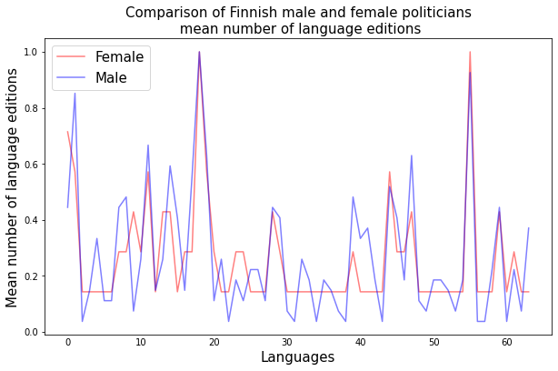

```python
print("Mean number of language editions for male Finnish politicians: {:3f}".format(number_lang_editions_male/num_male))
print("Mean number of language editions for female Finnish politicians: {:3f}".format(number_lang_editions_female/num_female))

for gender in gender_counts:
    for lang in gender_counts[gender]:
        gender_counts[gender][lang] /= count[gender]


sorted_counts = dict(sorted(gender_counts['M'].items(), key=lambda x: x[1], reverse=True))

common_langs = sorted(list(set(gender_counts['M'].keys()).intersection(set(gender_counts['F'].keys()))))

num_females_morethan_males = 0
num_males_morethan_females = 0

num_females_morethan_males_list = []
num_males_morethan_females_list = []

for lang in common_langs:
    if gender_counts['M'][lang] > gender_counts['F'][lang]:
        num_males_morethan_females += 1
        num_males_morethan_females_list.append(lang)
    elif gender_counts['M'][lang] < gender_counts['F'][lang]:
        num_females_morethan_males += 1
        num_females_morethan_males_list.append(lang)

print(f"Number of languages covering more Finnish female politicians than male politicians: {num_females_morethan_males}")
print(f"Number of languages covering more Finnish male politicians than female politicians: {num_males_morethan_females}")

females_mean_list = []
males_mean_list = []
for lang in common_langs:
    males_mean_list.append(gender_counts['M'][lang])
    females_mean_list.append(gender_counts['F'][lang])

fontsize=15
plt.figure(figsize=(10,6))
plt.tick_params(axis='x', which='both', length=0)
plt.plot(range(0, len(females_mean_list)), females_mean_list, label="Female", c='r', alpha=0.5)
plt.plot(range(0, len(males_mean_list)), males_mean_list, label="Male", c='b', alpha=0.5)

plt.xlabel("Languages",fontsize=fontsize)
plt.ylabel("Mean number of language editions",fontsize=fontsize)
plt.title("Comparison of Finnish male and female politicians\n mean number of language editions",fontsize=fontsize)
plt.legend(fontsize=fontsize)
```

Studying the gender biased language for artists (any kind of artists - singer, composer, director, painter, etc.)

```python
male_artists = {name: data for name, data in artists.items() if data["gender"] == "M"}

num_male = len(male_artists)

female_artists = {name: data for name, data in artists.items() if data["gender"] == "F"}

num_female = len(female_artists)

# Concatenate all summaries into a single string
all_summaries = " ".join([data["summary"] for data in artists.values()])

# Separate summaries by gender
male_summaries = " ".join([data["summary"] for data in artists.values() if data["gender"] == "M"])
female_summaries = " ".join([data["summary"] for data in artists.values() if data["gender"] == "F"])

# Count occurrences of personal and professional terms
family_terms = ["husband", "wife", "spouse", "mother", "mom", "father", "dad", "son", "daughter", "married", "divorced", "family", "child", "children"]
professional_terms = ["leader", "president", "prime", "minister", "politician", "government", "parliamenet", "official", "public", "service", "governor", "senator"]

male_family_counts = sum([male_summaries.lower().count(term) for term in family_terms])/num_male
female_family_counts = sum([female_summaries.lower().count(term) for term in family_terms])/num_female
male_professional_counts = sum([male_summaries.lower().count(term) for term in professional_terms])/num_male
female_professional_counts = sum([female_summaries.lower().count(term) for term in professional_terms])/num_female

# Print results
print(f"Average occurence of personal terms for artists: Male: {round(male_family_counts, 3)}, Female: {round(female_family_counts, 3)}")
print(f"Average occurence of professional terms for artists: Male: {round(male_professional_counts, 3)}, Female: {round(female_professional_counts, 3)}")
```

```
Average occurence of personal terms for artists: Male: 0.818, Female: 1.069
Average occurence of professional terms for artists: Male: 0.214, Female: 0.19
```

Replicate the analysis of comparing if females/males are more likely to be “local heroes,” i.e., if it is true that females are more likely to be in a larger number of language editions than males for artists

```python
gender_counts = {'M': {}, 'F': {}, 'NA': {}}

female_artists = {name: data for name, data in artists.items() if data["gender"] == "F"}

num_female = len(female_artists)

male_artists = {name: data for name, data in artists.items() if data["gender"] == "M"}

num_male = len(male_artists)

NA_artists = {name: data for name, data in artists.items() if data["gender"] == "NA"}

num_NA = len(NA_artists)

count = {'M': num_male, 'F': num_female, 'NA': num_NA}
for name, data in artists.items():
    gender = data['gender']
    langs = data['langs']

    for lang in langs:
        if lang not in gender_counts[gender]:
            gender_counts[gender][lang] = 1
        else:
            gender_counts[gender][lang] += 1

number_lang_editions_male = sum(gender_counts['M'].values())
number_lang_editions_female = sum(gender_counts['F'].values())
```

```
Mean number of language editions for male artists: 8.399824
Mean number of language editions for female artists: 9.884726
Number of languages covering more female artists than male artists: 102
Number of languages covering more male artists than female artists: 46
```

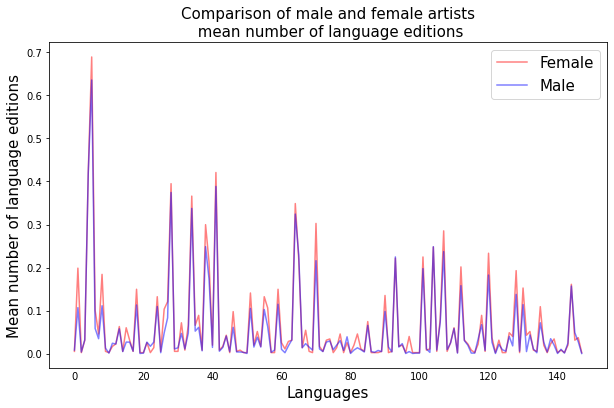

```python
print("Mean number of language editions for male artists: {:3f}".format(number_lang_editions_male/num_male))
print("Mean number of language editions for female artists: {:3f}".format(number_lang_editions_female/num_female))

for gender in gender_counts:
    for lang in gender_counts[gender]:
        gender_counts[gender][lang] /= count[gender]


sorted_counts = dict(sorted(gender_counts['M'].items(), key=lambda x: x[1], reverse=True))

common_langs = sorted(list(set(gender_counts['M'].keys()).intersection(set(gender_counts['F'].keys()))))

num_females_morethan_males = 0
num_males_morethan_females = 0

num_females_morethan_males_list = []
num_males_morethan_females_list = []

for lang in common_langs:
    if gender_counts['M'][lang] > gender_counts['F'][lang]:
        num_males_morethan_females += 1
        num_males_morethan_females_list.append(lang)
    elif gender_counts['M'][lang] < gender_counts['F'][lang]:
        num_females_morethan_males += 1
        num_females_morethan_males_list.append(lang)

print(f"Number of languages covering more female artists than male artists: {num_females_morethan_males}")
print(f"Number of languages covering more male artists than female artists: {num_males_morethan_females}")

females_mean_list = []
males_mean_list = []
for lang in common_langs:
    males_mean_list.append(gender_counts['M'][lang])
    females_mean_list.append(gender_counts['F'][lang])

fontsize=15
plt.figure(figsize=(10,6))
plt.tick_params(axis='x', which='both', length=0)
plt.plot(range(0, len(females_mean_list)), females_mean_list, label="Female", c='r', alpha=0.5)
plt.plot(range(0, len(males_mean_list)), males_mean_list, label="Male", c='b', alpha=0.5)

plt.xlabel("Languages",fontsize=fontsize)
plt.ylabel("Mean number of language editions",fontsize=fontsize)
plt.title("Comparison of male and female artists\n mean number of language editions",fontsize=fontsize)
plt.legend(fontsize=fontsize)
```